# CLT Convergence: Six-Sided Die

```r
source("../R/clt_functions.R")

student_id <- 8515     # last 4 digits of my student ID
B          <- 10000    # number of simulated samples (NOT the sample size)
pop        <- "die"
```

## 1. What does the population look like?

X is uniform on {1, 2, 3, 4, 5, 6}, generated with `sample()`. Discrete, symmetric, flat.

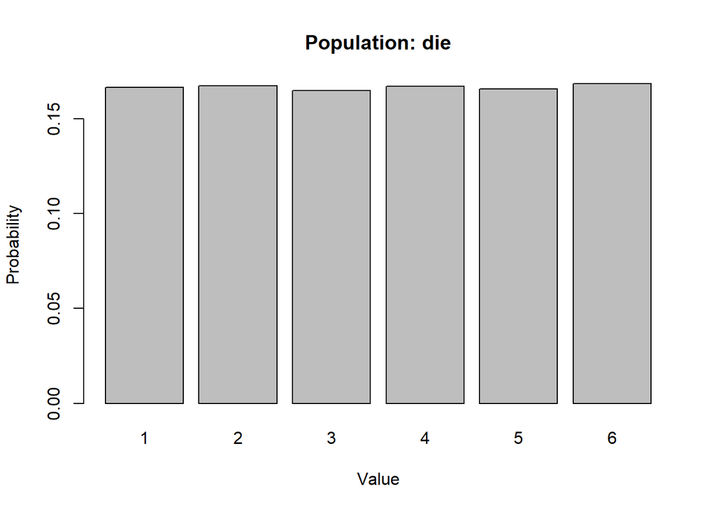

```r
plot_population(pop, seed = student_id)
```

The population is discrete: each value from 1 to 6 has equal probability 1/6, so the bar chart is flat. It is perfectly symmetric (skewness = 0) but has no tails at all: values can never go below 1 or above 6. It is flatter than a normal curve, with excess kurtosis of about −1.27. It satisfies every CLT assumption (independent, identically distributed, finite variance), so the CLT applies. The main features to watch are the flat shape and the gaps between possible values.

## 2. Theoretical mean and standard deviation

Theoretical mean = 3.5, SD = √(35/12) ≈ 1.708, so SE(X̄) = 1.708/√n.

## 3. Prediction (write this BEFORE running the simulations)

Prediction: The die is symmetric, so I expect skewness to be close to 0 at every n. Because it is flat (uniform) with no tails, it is already closer to normal than the exponential, so I predict it will look normal fairly quickly, around n = 5–10, well under 30. Since the die is discrete, I expect the histogram to look choppy at small n. I expect the simulated mean to be near 3.5 and the SE to match 1.708/√n.

## 4. Which sample sizes did I investigate?

**Pass 1 (coarse):** a wide grid to find roughly where the change happens.

```r
ns_coarse <- c(2, 5, 10, 20, 30, 50, 100, 200, 500)
coarse    <- run_study(pop, ns_coarse, B = B, seed = student_id)
knitr::kable(coarse$table, digits = 4)
```

| n | sim_mean | theo_mean | sim_se | theo_se | se_ratio | skewness | ex_kurt | qq_cor | shapiro_p |
| --- | --- | --- | --- | --- | --- | --- | --- | --- | --- |
| 2 | 3.4995 | 3.5 | 1.2043 | 1.2076 | 0.9973 | -0.0017 | -0.6491 | 0.9874 | 0.0000 |
| 5 | 3.5024 | 3.5 | 0.7535 | 0.7638 | 0.9865 | -0.0088 | -0.2426 | 0.9967 | 0.0000 |
| 10 | 3.5040 | 3.5 | 0.5349 | 0.5401 | 0.9905 | -0.0105 | -0.1153 | 0.9984 | 0.0000 |
| 20 | 3.5005 | 3.5 | 0.3752 | 0.3819 | 0.9824 | -0.0149 | 0.0609 | 0.9992 | 0.0000 |
| 30 | 3.5000 | 3.5 | 0.3081 | 0.3118 | 0.9882 | -0.0222 | -0.0208 | 0.9994 | 0.0003 |
| 50 | 3.5007 | 3.5 | 0.2394 | 0.2415 | 0.9912 | 0.0227 | 0.0239 | 0.9996 | 0.0153 |
| 100 | 3.5014 | 3.5 | 0.1678 | 0.1708 | 0.9825 | 0.0184 | -0.0367 | 0.9998 | 0.1120 |
| 200 | 3.5010 | 3.5 | 0.1199 | 0.1208 | 0.9926 | 0.0082 | -0.0953 | 0.9998 | 0.1702 |
| 500 | 3.5008 | 3.5 | 0.0765 | 0.0764 | 1.0019 | -0.0352 | -0.0207 | 0.9999 | 0.1311 |

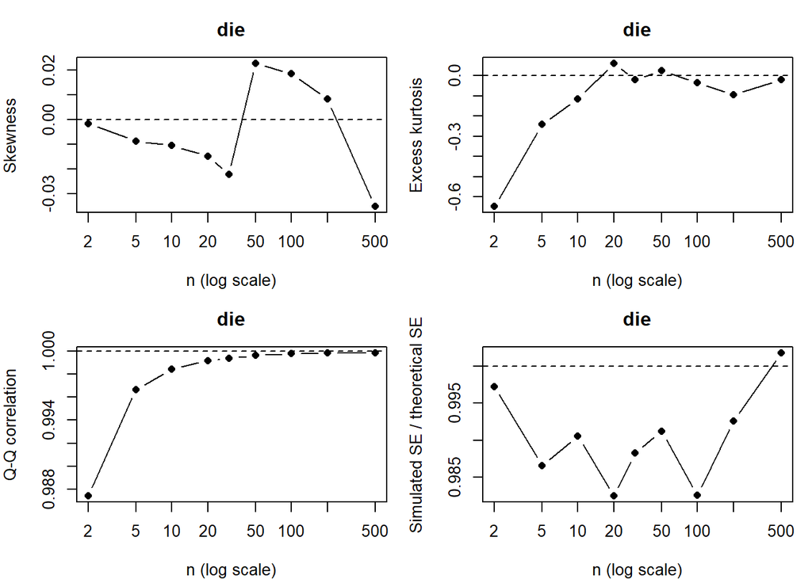

```r
plot_convergence(coarse$table, pop)
```

**Pass 2 (refined):** narrower values around the transition.

```r
ns_fine <- c(3, 4, 5, 6, 7, 8, 9, 10, 12, 15)   # pass 1 changed between n = 5 and n = 10
fine    <- run_study(pop, ns_fine, B = B, seed = student_id)
knitr::kable(fine$table, digits = 4)
```

| n | sim_mean | theo_mean | sim_se | theo_se | se_ratio | skewness | ex_kurt | qq_cor | shapiro_p |
| --- | --- | --- | --- | --- | --- | --- | --- | --- | --- |
| 3 | 3.5020 | 3.5 | 0.9807 | 0.9860 | 0.9946 | 0.0171 | -0.3342 | 0.9939 | 0 |
| 4 | 3.5016 | 3.5 | 0.8500 | 0.8539 | 0.9954 | 0.0084 | -0.3010 | 0.9957 | 0 |
| 5 | 3.5024 | 3.5 | 0.7535 | 0.7638 | 0.9865 | -0.0088 | -0.2426 | 0.9967 | 0 |
| 6 | 3.5023 | 3.5 | 0.6953 | 0.6972 | 0.9972 | 0.0131 | -0.1709 | 0.9974 | 0 |
| 7 | 3.5009 | 3.5 | 0.6448 | 0.6455 | 0.9990 | -0.0066 | -0.1485 | 0.9978 | 0 |
| 8 | 3.5024 | 3.5 | 0.6042 | 0.6038 | 1.0006 | -0.0131 | -0.1931 | 0.9980 | 0 |
| 9 | 3.5028 | 3.5 | 0.5647 | 0.5693 | 0.9919 | -0.0235 | -0.1684 | 0.9981 | 0 |
| 10 | 3.5040 | 3.5 | 0.5349 | 0.5401 | 0.9905 | -0.0105 | -0.1153 | 0.9984 | 0 |
| 12 | 3.5033 | 3.5 | 0.4919 | 0.4930 | 0.9978 | -0.0142 | -0.1543 | 0.9986 | 0 |
| 15 | 3.5018 | 3.5 | 0.4359 | 0.4410 | 0.9884 | -0.0107 | 0.0052 | 0.9989 | 0 |

In pass 1, n = 5 failed my standard and n = 10 passed, so the change happens between them. I refined with every value from 3 to 10, plus 12 and 15, to find the exact crossing point.

## 5. Simulated vs. theoretical mean and standard error

The table columns `sim_mean` / `theo_mean` and `sim_se` / `theo_se` compare the simulation with the CLT’s predictions. `se_ratio` = simulated SE ÷ σ/√n, so 1 means a perfect match.

The simulated mean was within 0.004 of the theoretical mean of 3.5 at every n, and the SE ratio stayed between 0.98 and 1.00. The simulation agrees with σ/√n = 1.708/√n at every sample size, even at n = 2 where the shape is not normal.

## 6. My “normal enough” standard and the chosen n

```r
# My "normal enough" standard, used identically in every file
criteria <- list(
  max_abs_skew = 0.25,    # mild skew; tighter is within Monte Carlo noise
  max_abs_kurt = 0.3,     # tails close to normal
  min_qq_cor   = 0.998    # Q-Q plot essentially straight
)

all_results <- rbind(coarse$table, fine$table)
all_results <- all_results[!duplicated(all_results$n), ]
all_results <- all_results[order(all_results$n), ]
all_results$passes <- passes_standard(all_results, criteria)
knitr::kable(all_results, digits = 4)
```

|  | n | sim_mean | theo_mean | sim_se | theo_se | se_ratio | skewness | ex_kurt | qq_cor | shapiro_p | passes |
| --- | --- | --- | --- | --- | --- | --- | --- | --- | --- | --- | --- |
| 1 | 2 | 3.4995 | 3.5 | 1.2043 | 1.2076 | 0.9973 | -0.0017 | -0.6491 | 0.9874 | 0.0000 | FALSE |
| 10 | 3 | 3.5020 | 3.5 | 0.9807 | 0.9860 | 0.9946 | 0.0171 | -0.3342 | 0.9939 | 0.0000 | FALSE |
| 11 | 4 | 3.5016 | 3.5 | 0.8500 | 0.8539 | 0.9954 | 0.0084 | -0.3010 | 0.9957 | 0.0000 | FALSE |
| 2 | 5 | 3.5024 | 3.5 | 0.7535 | 0.7638 | 0.9865 | -0.0088 | -0.2426 | 0.9967 | 0.0000 | FALSE |
| 13 | 6 | 3.5023 | 3.5 | 0.6953 | 0.6972 | 0.9972 | 0.0131 | -0.1709 | 0.9974 | 0.0000 | FALSE |
| 14 | 7 | 3.5009 | 3.5 | 0.6448 | 0.6455 | 0.9990 | -0.0066 | -0.1485 | 0.9978 | 0.0000 | FALSE |
| 15 | 8 | 3.5024 | 3.5 | 0.6042 | 0.6038 | 1.0006 | -0.0131 | -0.1931 | 0.9980 | 0.0000 | FALSE |
| 16 | 9 | 3.5028 | 3.5 | 0.5647 | 0.5693 | 0.9919 | -0.0235 | -0.1684 | 0.9981 | 0.0000 | TRUE |
| 3 | 10 | 3.5040 | 3.5 | 0.5349 | 0.5401 | 0.9905 | -0.0105 | -0.1153 | 0.9984 | 0.0000 | TRUE |
| 18 | 12 | 3.5033 | 3.5 | 0.4919 | 0.4930 | 0.9978 | -0.0142 | -0.1543 | 0.9986 | 0.0000 | TRUE |
| 19 | 15 | 3.5018 | 3.5 | 0.4359 | 0.4410 | 0.9884 | -0.0107 | 0.0052 | 0.9989 | 0.0000 | TRUE |
| 4 | 20 | 3.5005 | 3.5 | 0.3752 | 0.3819 | 0.9824 | -0.0149 | 0.0609 | 0.9992 | 0.0000 | TRUE |
| 5 | 30 | 3.5000 | 3.5 | 0.3081 | 0.3118 | 0.9882 | -0.0222 | -0.0208 | 0.9994 | 0.0003 | TRUE |
| 6 | 50 | 3.5007 | 3.5 | 0.2394 | 0.2415 | 0.9912 | 0.0227 | 0.0239 | 0.9996 | 0.0153 | TRUE |
| 7 | 100 | 3.5014 | 3.5 | 0.1678 | 0.1708 | 0.9825 | 0.0184 | -0.0367 | 0.9998 | 0.1120 | TRUE |
| 8 | 200 | 3.5010 | 3.5 | 0.1199 | 0.1208 | 0.9926 | 0.0082 | -0.0953 | 0.9998 | 0.1702 | TRUE |
| 9 | 500 | 3.5008 | 3.5 | 0.0765 | 0.0764 | 1.0019 | -0.0352 | -0.0207 | 0.9999 | 0.1311 | TRUE |

```r
smallest_normal_n(all_results, criteria)
```

```
[1] 9
```

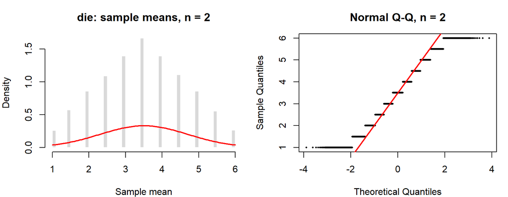

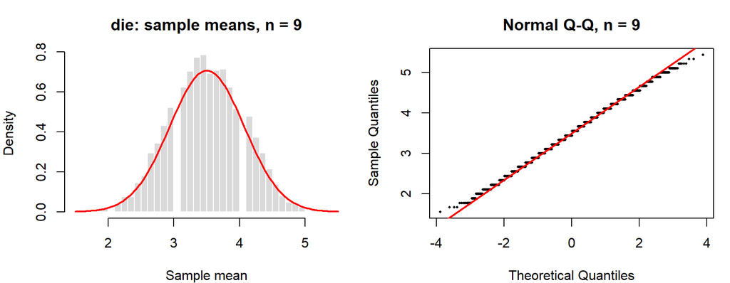

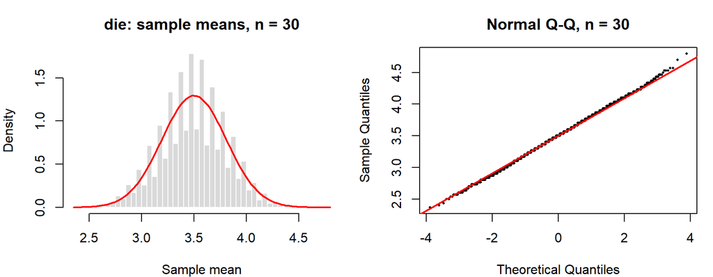

```r
# Show values below, at, and above my chosen n
for (n in c(2, 9, 30)) {
  plot_diagnostics(simulate_means(populations[[pop]], n, B, student_id), n, pop)
}
```

$$\boxed{n = \text{9}}$$

I used the same standard as every other population: |skewness| ≤ 0.25, |excess kurtosis| ≤ 0.3, and Q-Q correlation ≥ 0.998. Skewness passed at every n. Kurtosis passed from n = 5 on (−0.24). The Q-Q correlation was the last to pass: it was 0.99795 at n = 8, just below the cutoff, and 0.99813 at n = 9, and it stayed above 0.998 at every larger n. The Q-Q plot at n = 2 shows clear steps, while at n = 9 the points follow the line closely with only small steps. The histogram at n = 9 is bell-shaped and matches the red curve. The Shapiro-Wilk test still rejected normality until about n = 100, because it detects the discreteness that remains, which does not matter in practice.